# Introduction to R

## Goals of today' session:

- Load packages
- Visualization
- Tidy data
- Data wrangling

## Load packages

## Load packages

A package is a collection of previously programmed functions, often including functions for specific tasks. It is tempting to call this a library, but the R community refers to it as a package.

There are two types of packages: those that come with the base installation of R and packages that you must manually download and install using `install.packages("package")`. You can load a package with `library(package)`.

One very powerful graphics package is **ggplot2**.

```r
install.packages("ggplot2")
library(ggplot2)
```

You only need to install a package once, but you need to load it every time you start a new R-Session!

## Namespace

Sometimes functions from different packages have a common name (e.g., `select()` in the **raster** and **dplyr** packages). We therefore need to tell R which function it should use by defining the namespace for the function:

```r
raster::select()
dplyr::select()
```

## Visualization

## R base graphics

R's `base` graphics are great for quick visualization of your data. The main base graphics functions are `plot()`, `hist()` und `boxplot()`:

```r
hist(airquality[ , c("Ozone")])
```

```r
plot(airquality[ , c("Ozone")], airquality[ , c("Temp")])
```

```r
boxplot(airquality[ , c("Ozone")] ~ airquality[ , c("Month")])
```

## R base graphics: Histogram

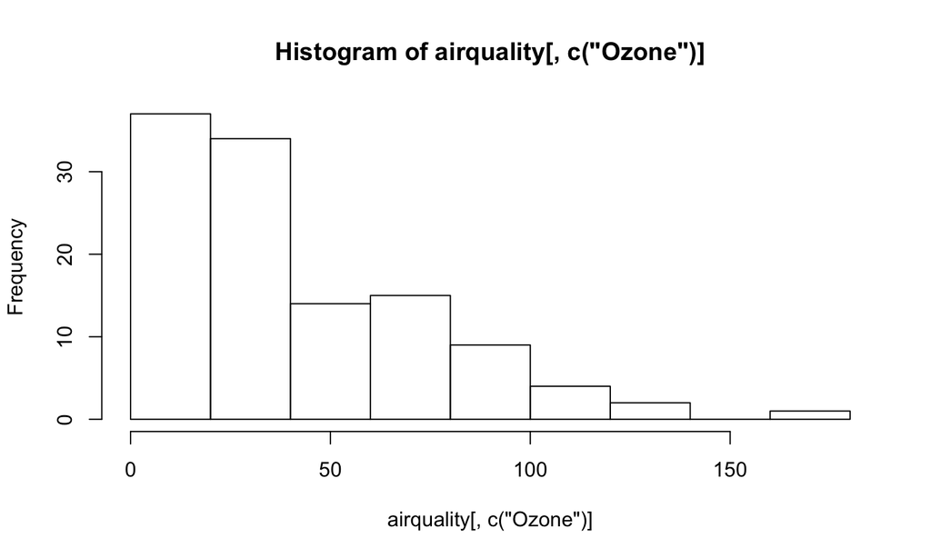

## R base graphics: Scatterplot

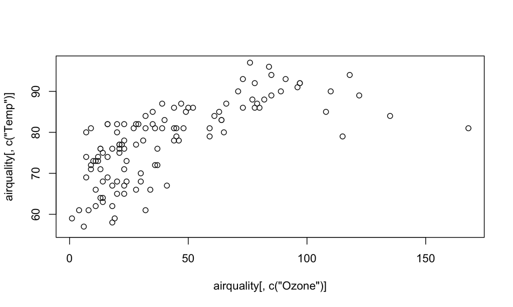

## R base graphics: Boxplot

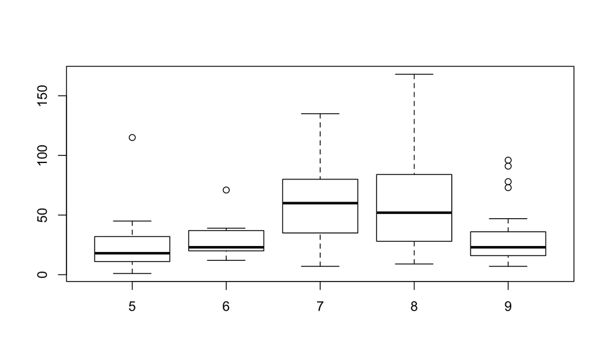

## ggplot2

The base graphics system can also be used visualize complex datasets and relationships, but you will need to write your own functions. The external **ggplot2** package is a great alternative:

```r
library(ggplot2)

ggplot(data = airquality, aes(x = Ozone)) +
  geom_histogram()
```

## ggplot2: Histogram

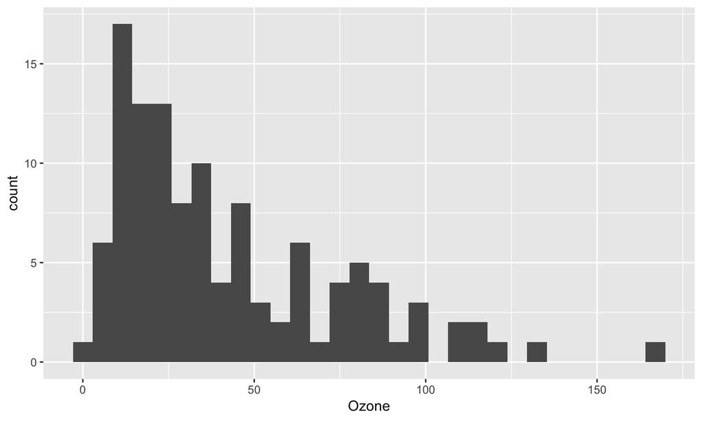

## ggplot2: Geom and aesthetics

The ggplot2 package works somewhat differently than the base graphics. When you call a ggplot you have to define **aesthetics** and one or multiple **geom** layers, e.g. `geom_histogram` in the previous example or `geom_point` in the following example.

```r
ggplot(data = airquality, aes(x = Ozone, y = Temp)) +
  geom_point()
```

```r
ggplot(data = airquality, aes(x = factor(Month), y = Ozone)) +
  geom_boxplot()
```

## ggplot2: Scatterplot

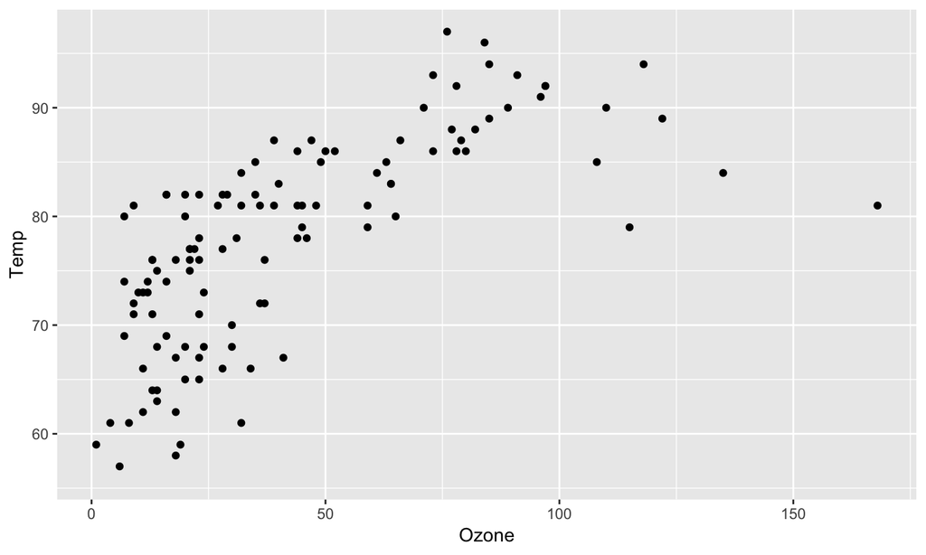

## ggplot2: Boxplot

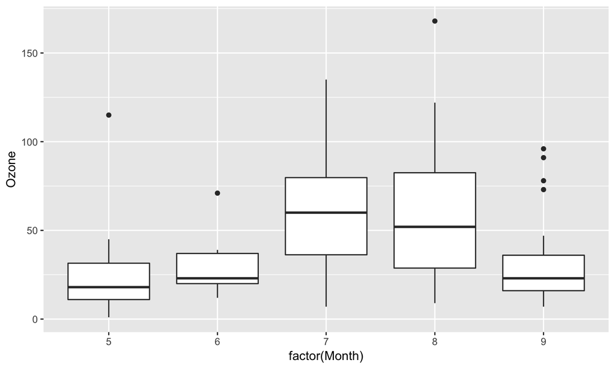

## ggplot2: Grouping by factor

You can use factor variables to change the **aesthetics** of `geom_point` and `geom_line` layers. The following example visualizes the data from different months with different colors.

```r
ggplot(data = airquality, aes(x = Ozone, y = Temp, col = factor(Month))) +
  geom_point()
```

## ggplot2: Grouping by factor

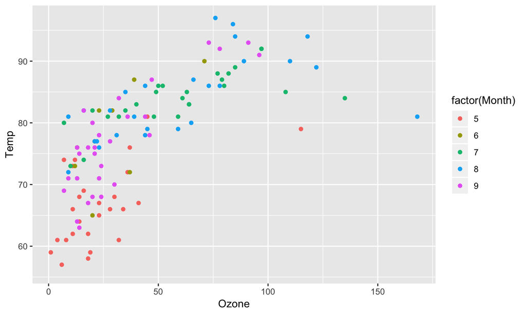

## ggplot2: Grouping by factor

You can also display factors through different symbols (with `geom_point`):

```r
ggplot(data = airquality, aes(x = Ozone, y = Temp, shape  = factor(Month))) +
  geom_point()
```

## ggplot2: Grouping by factor

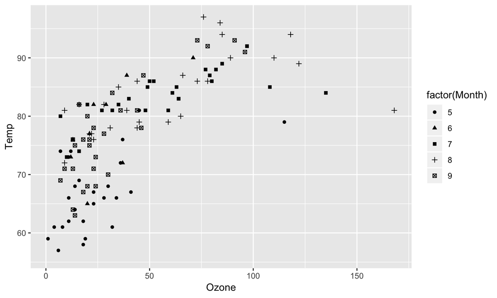

## ggplot2: Grouping by factor

…or the line type with `geom_line`:

```r
ggplot(data = airquality, aes(x = Day, y = Temp, linetype = factor(Month))) +
  geom_line()
```

## ggplot2: Grouping by factor

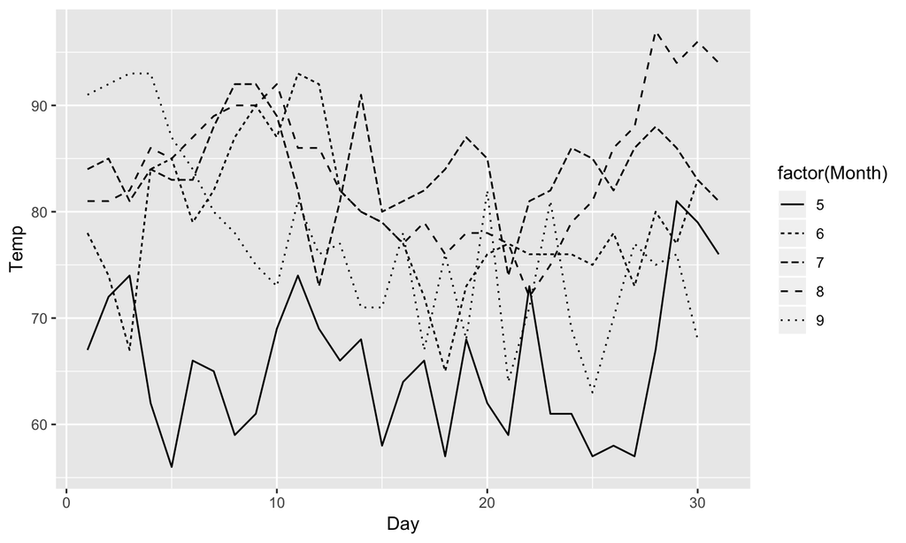

## ggplot2: Grouping by factor

..or the fill color of `geom_boxplot` and `geom_histogram`:

```r
ggplot(data = airquality, aes(x = Ozone, fill = factor(Month))) +
  geom_histogram()
```

## ggplot2: Grouping by factor

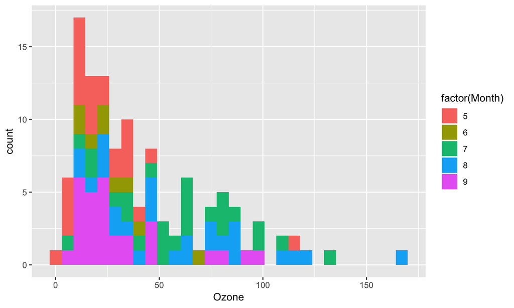

## ggplot2: Scaling by numeric variables

Factors can be used to define colors and symbols. Numeric varibles can be displayed by varying symbol sizes and color gradients:

```r
ggplot(data = airquality, aes(x = Ozone, y = Temp, col = Wind, size = Solar.R)) +
  geom_point()
```

## ggplot2: Scaling by numeric variables

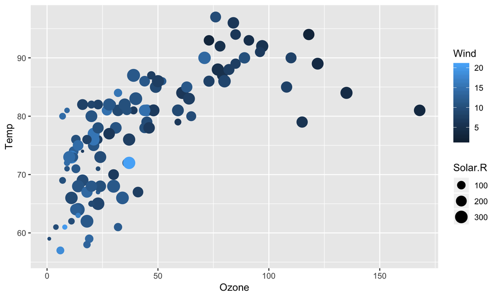

## ggplot2: Trellis graphs

Trellis plots are based on the idea of conditioning on the values taken on by one or more of the variables in a data set.

In the case of a categorical variable, this means carrying out the same plot for the data subsets corresponding to each of the levels of that variable.

R provides built-in trellis graphics with the `lattice` package.

In `ggplot2` trellis plots (here called multi-facet plots) can be achieved with `facet_wrap()`:

```r
ggplot(data = airquality, aes(x = Ozone, y = Temp)) +
  geom_point() +
  facet_wrap(~Month)
```

## ggplot2: Trellis graphs

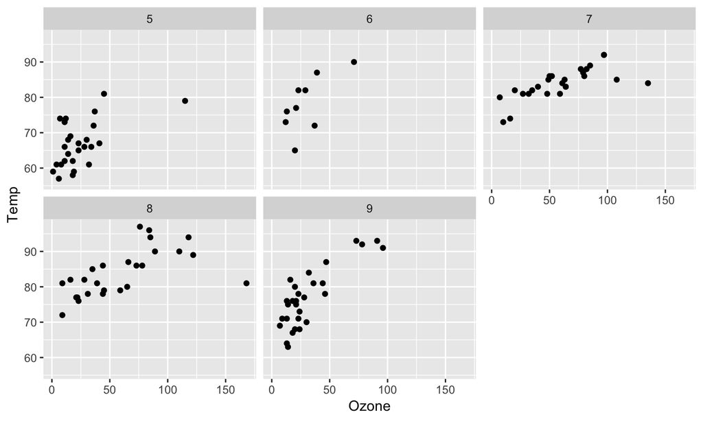

## ggplot2: Trellis graphs

The axes among individual plots (pannels) can be either fixed or variable (free):

```r
ggplot(data = airquality, aes(x = Ozone, y = Temp)) +
  geom_point() +
  facet_wrap(~Month, scales = "free")
```

additional arguments: `free`, `free_x` und `free_y`

## ggplot2: Trellis graphs

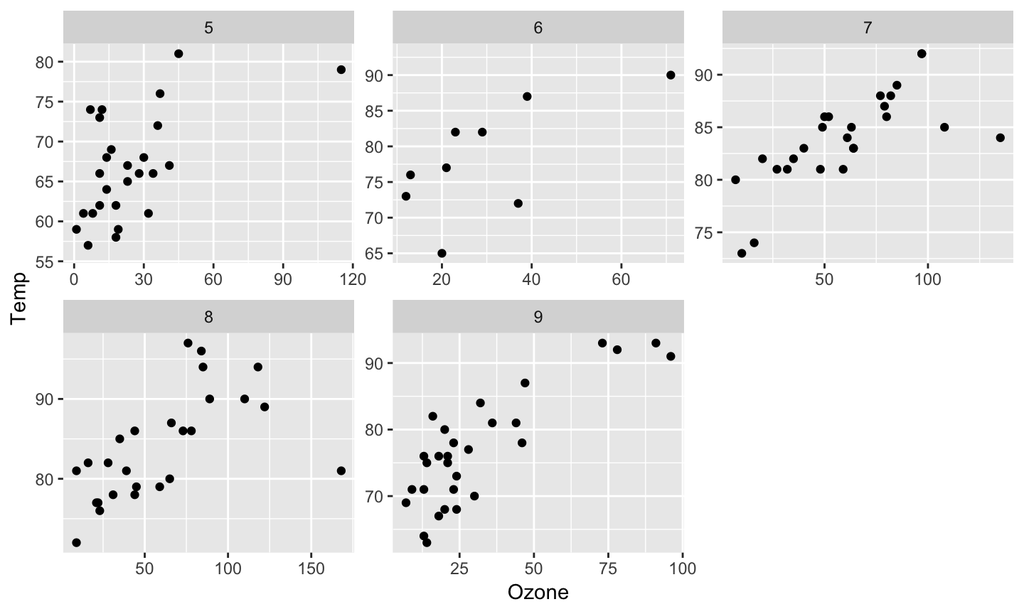

## ggplot2: Combining multiple layers

A ggplot can contain multiple layers and each layer can have its own `aesthetics`:

```r
ggplot(data = airquality, aes(x = Day, y = Temp)) +
  geom_point(aes(size = Ozone)) +
  geom_line(aes(linetype = factor(Month)))
```

## ggplot2: Combining multiple layers

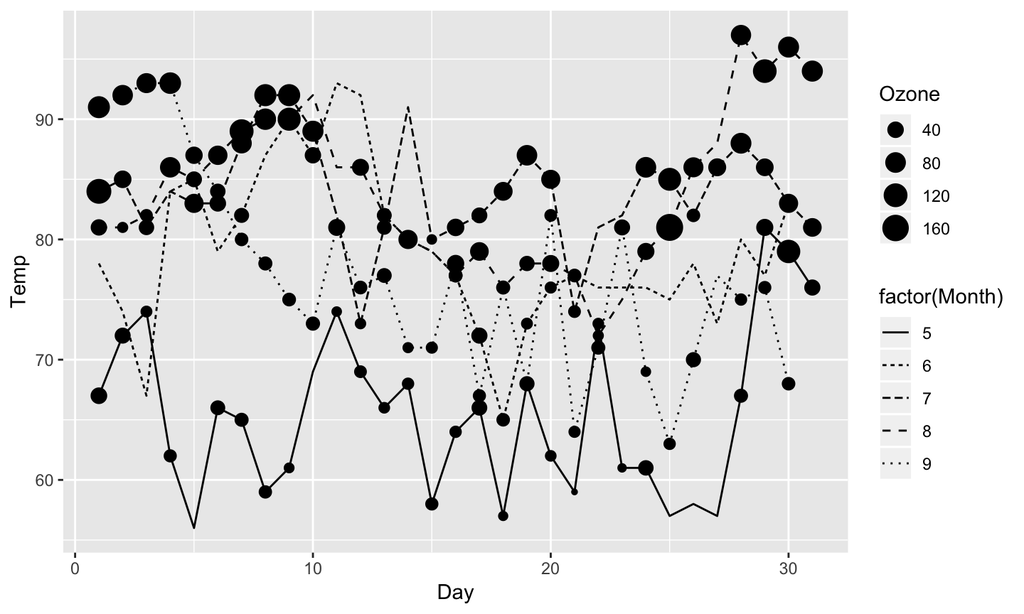

## ggplot2: Axis text and plot title

```r
ggplot(data = airquality, aes(x = Ozone, y = Temp, col = factor(Month))) +
  geom_point() +
  labs(x = "Ozone concentration [ppm]",
       y = "Temperature [°F]",
       title = "Relationship between Ozone und Temperture in New York")
```

## ggplot2: Axis text and plot title

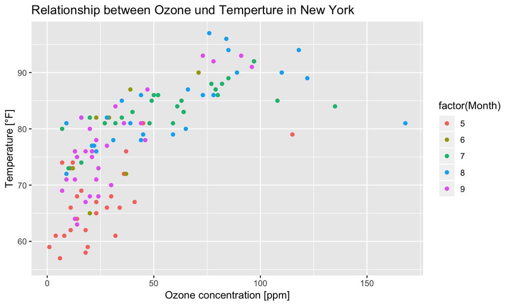

## Multi-plot graphics

You can combine multiple plots in a single graphic layout with `grid.arrange()` of the **gridExtra** package. First, you must create a graphics object for each plot. Then the two objects are combined with `grid.arrange()`.

```r
plot1 <- ggplot(data = airquality, aes(x = Ozone, y = Temp)) + geom_point()
plot2 <- ggplot(data = airquality, aes(x = Ozone, y = Wind)) + geom_point()

library(gridExtra)

grid.arrange(plot1, plot2, ncol = 2)
```

## Multi-plot graphics

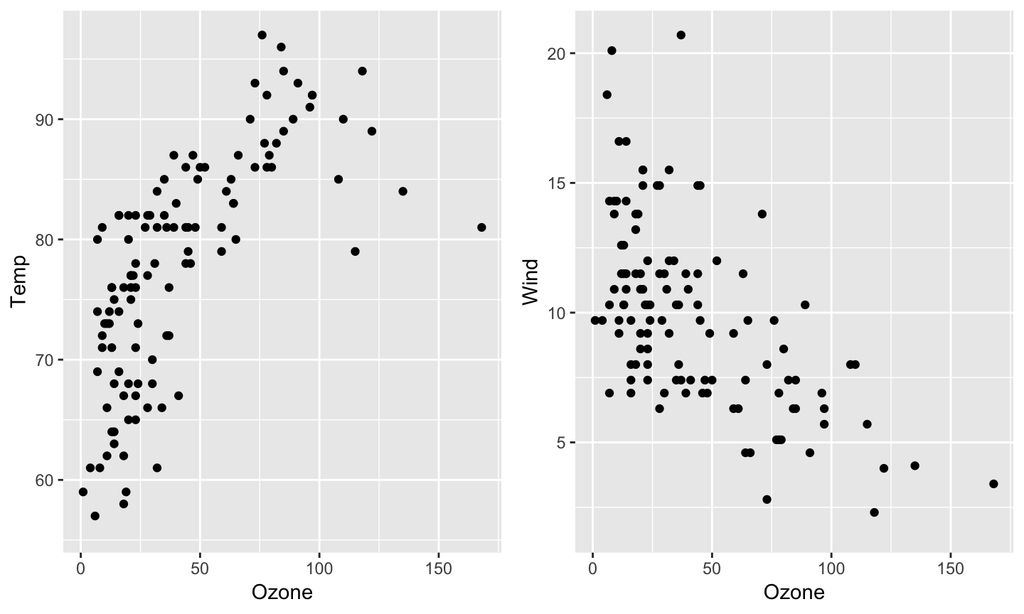

## Graphics file formats

R graphics can be exported into a number of file formats:

- pdf
- tiff
- png
- jpg
- …

## Graphics file formats

To export graphics you need to 'open' a new **Graphic Device** before running your plot functions and close it when you are done. The 'opening' function depends on the format (e.g. `pdf()`, `tif()`, `png()`, etc.). To close the graphics device you need to call `dev.off()`.

```r
pdf(file = "Figures/scatterplot01.pdf", width = 7, height = 5)

ggplot(data = airquality, aes(x = Ozone, y = Temp, col = factor(Month))) +
  geom_point()

dev.off()
```

## Graphics file formats

Alternatively, you cann use the `ggsave()` function.

```r
p <- ggplot(data = airquality, aes(x = Ozone, y = Temp, col = factor(Month))) +
  geom_point()

ggsave(filename = "plot.pdf", plot = p, path = "Figures")
```

## Tidy data and data wrangling

## Tidy data

Cleaning and preparing (tidying) data for analysis can make up a substantial proportion of the time spent on a project. It is therefore good practice to follow certain guidelines for structuring your data (see: H. Wickam (2014) Tidy data. Journal of Statistical Software, 59, 1-23):

1. Each variable forms a column.
2. Each observation forms a row.
3. Each type of observational unit forms a table.

## Tidy data

Real datasets can, and often do, violate the three precepts of tidy data in almost every way imaginable. While occasionally you do get a dataset that you can start analysing immediately, this is the exception, not the rule. This section describes the five most common problems with messy datasets, along with their remedies:

- Column headers are values, not variable names.
- Multiple variables are stored in one column.
- Variables are stored in both rows and columns.
- Multiple types of observational units are stored in the same table.
- A single observational unit is stored in multiple tables.

Most messy datasets, including types of messiness not explicitly described above, can be tidied with a small set of tools.

## Tidy data

Basically, data is often recoreded in this format (wide-format):

| Plot | Measure1 | Measure2 |
| --- | --- | --- |
| 1 | 13.1 | 12.7 |
| 2 | 9.5 | 10.6 |
| 3 | 11.9 | 7.4 |

## Tidy data

But we want to have it in following format (long-format)

| Plot | Measure | Value |
| --- | --- | --- |
| 1 | M1 | 13.1 |
| 2 | M1 | 9.5 |
| 3 | M1 | 11.9 |
| 1 | M2 | 12.7 |
| 2 | M2 | 10.6 |
| 3 | M2 | 7.4 |

## Tidying messy datasets

```r
yields <- read.table("Data/yields.txt", sep = ";", header = TRUE)

yields[1:5, ]
```

```
##   plotid sand clay loam
## 1      1    6   17   13
## 2      2   10   15   16
## 3      3    8    3    9
## 4      4    6   11   12
## 5      5   14   14   15
```

## Tidying messy datasets

The `gather()` function in the **tidyr** package can be used to convert the previous dataset into a *tidy* dataset:

```r
library(tidyr)

yields_tidy <- gather(yields, key = soiltype, value = yield, -plotid)

yields_tidy[c(1:3, 11:13), ]
```

```
##    plotid soiltype yield
## 1       1     sand     6
## 2       2     sand    10
## 3       3     sand     8
## 11      1     clay    17
## 12      2     clay    15
## 13      3     clay     3
```

## Tidying messy datasets

The dataset is now tidy, i.e. ready for analysis and plotting:

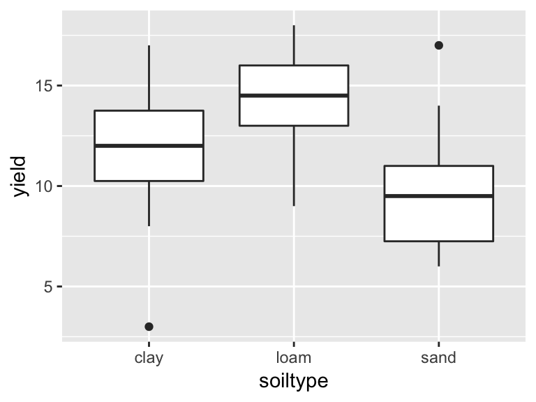

```r
ggplot(yields_tidy, aes(x = soiltype, y = yield)) +
  geom_boxplot()
```

## Tidying messy datasets

Sometimes we want to back-transform the data into wide format, which can be done using the `spread()` function:

```r
yields <- spread(yields_tidy, key = soiltype, value = yield)

yields[1:3, ]
```

```
##   plotid clay loam sand
## 1      1   17   13    6
## 2      2   15   16   10
## 3      3    3    9    8
```

## Tidying messy datasets

Sometimes column names include several attributes:

```r
yields2 <- read.table("Data/yields2.txt", sep = ";", header = TRUE)

yields2[1:3, ]
```

```
##   plotid sand_fine clay_fine loam_fine sand_coarse clay_coarse loam_coarse
## 1      1         6        17        13           9          18          15
## 2      2        10        15        16          10          15          18
## 3      3         8         3         9           9           3           9
```

## Tidying messy datasets

After transforming it into long format, the data still is not a tidy data set ('Multiple variables are stored in one column'):

```r
yields2_tidy <- gather(yields2, key = soiltype, value = yield, -plotid)

yields2_tidy[c(1:3, 11:13), ]
```

```
##    plotid  soiltype yield
## 1       1 sand_fine     6
## 2       2 sand_fine    10
## 3       3 sand_fine     8
## 11      1 clay_fine    17
## 12      2 clay_fine    15
## 13      3 clay_fine     3
```

## Tidying messy datasets

We need to split the 'soiltype' column into two columns 'soildtype' and 'grain'. This can easily be done using the `separate()` function:

```r
yields2_tidy <- separate(yields2_tidy, col = soiltype, into = c("soiltype", "grain"), sep = "_")

yields2_tidy[c(1:3, 11:13), ]
```

```
##    plotid soiltype grain yield
## 1       1     sand  fine     6
## 2       2     sand  fine    10
## 3       3     sand  fine     8
## 11      1     clay  fine    17
## 12      2     clay  fine    15
## 13      3     clay  fine     3
```

Which can now be nicely plotted using ggplot2:

```r
ggplot(yields2_tidy, aes(x = soiltype, y = yield, fill = grain)) +
  geom_boxplot()
```

## Tidying messy datasets

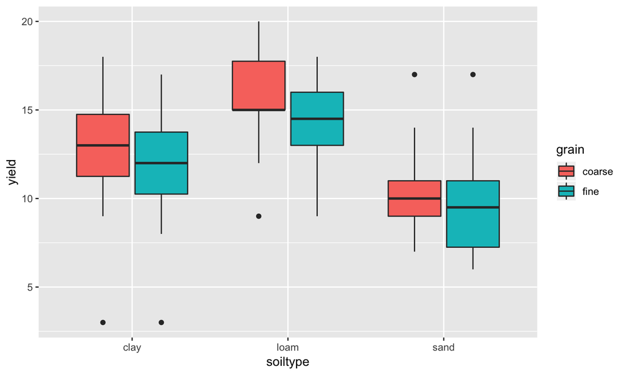

## Pipes

Often we have to do many steps to wrangel our data into a tidy form, which can become messy and un-readible. This is especially true if we nest many steps into one line. Using so-called *pipes* in the **dplyr** package can help us:

```r
library(dplyr)

yields2_tidy <- yields2 %>%
  gather(., key = soiltype, value = yield, -plotid) %>%
  separate(., col = soiltype, into = c("soiltype", "grain"), sep = "_")
```

The term `x <- y %>% f1(.) %>% f2(.)` is similar to `x <- f2(f1(y))`, but more readable when the the statement is long!

## Mutating new variables

If we want to create a new variable (column), we can use the `mutate()` function:

```r
yields2_tidy <- yields2_tidy %>%
  mutate(yield_log = log(yield),
         yield_log10 = log10(yield))

yields2_tidy[1:3, ]
```

```
##   plotid soiltype grain yield yield_log yield_log10
## 1      1     sand  fine     6  1.791759   0.7781513
## 2      2     sand  fine    10  2.302585   1.0000000
## 3      3     sand  fine     8  2.079442   0.9030900
```

## Creating summaries

If we want to create a summary of (a) variable(s), we can use the `summarize()` function:

```r
yields2_tidy_summary <- yields2_tidy %>%
  summarize(yield_mean = mean(yield),
            yield_median = median(yield))

yields2_tidy_summary
```

```
##   yield_mean yield_median
## 1   12.36667           12
```

## Grouping data

Using **dyplr** we can easily calculate new variables or derive summaries of our data. However, often we want to do both wihtin specific groups, e.g. the mean/median yield within each soil-type and grain-class. We therefore need to group the data:

```r
yields2_tidy_summary <- yields2_tidy %>%
  group_by(soiltype, grain) %>%
  summarize(yield_mean = mean(yield),
            yield_median = median(yield))

yields2_tidy_summary
```

```
## # A tibble: 6 x 4
## # Groups:   soiltype [?]
##   soiltype grain  yield_mean yield_median
##   <chr>    <chr>       <dbl>        <dbl>
## 1 clay     coarse       12.4         13
## 2 clay     fine         11.5         12
## 3 loam     coarse       15.5         15
## 4 loam     fine         14.3         14.5
## 5 sand     coarse       10.6         10
## 6 sand     fine          9.9          9.5
```

## Tibbles

**Note:** The result from a dplyr call is a so-called *tibble*, which is similar to a data frame, but has some improvements. For example, it shows the data type and dimensions of the data frame, as well as it is easier to print in the console.

```
## # A tibble: 30 x 3
##    plotid soiltype yield
##     <int> <chr>    <int>
##  1      1 sand         6
##  2      2 sand        10
##  3      3 sand         8
##  4      4 sand         6
##  5      5 sand        14
##  6      6 sand        17
##  7      7 sand         9
##  8      8 sand        11
##  9      9 sand         7
## 10     10 sand        11
## # ... with 20 more rows
```

## Grouping data

We also can use the `mutate()` function within groups, e.g. for centering the yields within groups:

```r
yields2_tidy <- yields2_tidy %>%
  group_by(soiltype, grain) %>%
  mutate(yield_centered = yield - mean(yield))

yields2_tidy
```

```
## # A tibble: 60 x 7
## # Groups:   soiltype, grain [6]
##    plotid soiltype grain yield yield_log yield_log10 yield_centered
##     <int> <chr>    <chr> <int>     <dbl>       <dbl>          <dbl>
##  1      1 sand     fine      6      1.79       0.778        -3.9
##  2      2 sand     fine     10      2.30       1             0.1000
##  3      3 sand     fine      8      2.08       0.903        -1.9
##  4      4 sand     fine      6      1.79       0.778        -3.9
##  5      5 sand     fine     14      2.64       1.15          4.1
##  6      6 sand     fine     17      2.83       1.23          7.1
##  7      7 sand     fine      9      2.20       0.954        -0.9
##  8      8 sand     fine     11      2.40       1.04          1.10
##  9      9 sand     fine      7      1.95       0.845        -2.9
## 10     10 sand     fine     11      2.40       1.04          1.10
## # ... with 50 more rows
```

## Subsetting data

Often, we also want to exclude observations (rows), which we can easily do using the `filter()` function:

```r
yields2_tidy_subset <- yields2_tidy %>%
  filter(grain == "fine")
```

Similar, we can exclude variables (columns) that we don't need for further analysis using the `select()` function:

```r
yields2_tidy_subset <- yields2_tidy %>%
  select(-yield_log10, -yield_log)
```

Thereby we ca either select columns or drop them using a '-' before the columns name.

## More information on data wrangling using **dplyr**

There are many more options in the **dplyr** package. For a nice overview please see following cheat-sheet: https://www.rstudio.com/wp-content/uploads/2015/02/data-wrangling-cheatsheet.pdf